# Assignment 3

Emily Bates

2024-02-25

### Question 13

This question should be answered using the Weekly data set, which is part of the ISLR2 package. This data is similar in nature to the Smarket data from this chapter’s lab, except that it contains 1,089 weekly returns for 21 years, from the beginning of 1990 to the end of 2010.

1. Produce some numerical and graphical summaries of the Weekly data. Do there appear to be any patterns?

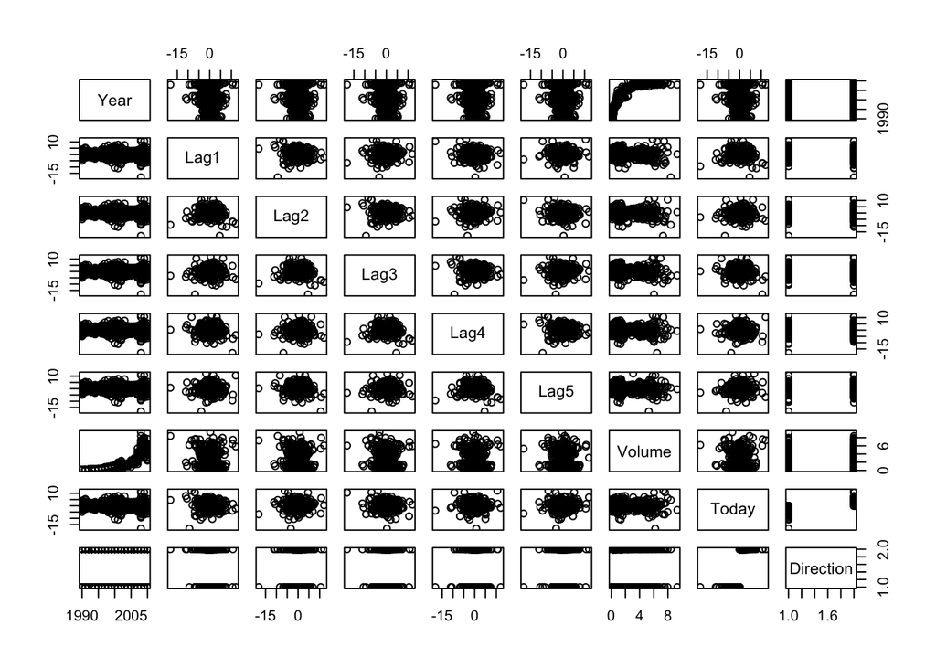

```r
library(ISLR2); library(corrplot); library(MASS); library(caret);
library(car); library(dplyr); library(class);library(e1071)
pairs(Weekly)
```

```r
summary(Weekly)
```

```
##       Year           Lag1               Lag2               Lag3
##  Min.   :1990   Min.   :-18.1950   Min.   :-18.1950   Min.   :-18.1950
##  1st Qu.:1995   1st Qu.: -1.1540   1st Qu.: -1.1540   1st Qu.: -1.1580
##  Median :2000   Median :  0.2410   Median :  0.2410   Median :  0.2410
##  Mean   :2000   Mean   :  0.1506   Mean   :  0.1511   Mean   :  0.1472
##  3rd Qu.:2005   3rd Qu.:  1.4050   3rd Qu.:  1.4090   3rd Qu.:  1.4090
##  Max.   :2010   Max.   : 12.0260   Max.   : 12.0260   Max.   : 12.0260
##       Lag4               Lag5              Volume            Today
##  Min.   :-18.1950   Min.   :-18.1950   Min.   :0.08747   Min.   :-18.1950
##  1st Qu.: -1.1580   1st Qu.: -1.1660   1st Qu.:0.33202   1st Qu.: -1.1540
##  Median :  0.2380   Median :  0.2340   Median :1.00268   Median :  0.2410
##  Mean   :  0.1458   Mean   :  0.1399   Mean   :1.57462   Mean   :  0.1499
##  3rd Qu.:  1.4090   3rd Qu.:  1.4050   3rd Qu.:2.05373   3rd Qu.:  1.4050
##  Max.   : 12.0260   Max.   : 12.0260   Max.   :9.32821   Max.   : 12.0260
##  Direction
##  Down:484
##  Up  :605
##
##
##
##
```

```r
str(Weekly)
```

```
## 'data.frame':    1089 obs. of  9 variables:
##  $ Year     : num  1990 1990 1990 1990 1990 1990 1990 1990 1990 1990 ...
##  $ Lag1     : num  0.816 -0.27 -2.576 3.514 0.712 ...
##  $ Lag2     : num  1.572 0.816 -0.27 -2.576 3.514 ...
##  $ Lag3     : num  -3.936 1.572 0.816 -0.27 -2.576 ...
##  $ Lag4     : num  -0.229 -3.936 1.572 0.816 -0.27 ...
##  $ Lag5     : num  -3.484 -0.229 -3.936 1.572 0.816 ...
##  $ Volume   : num  0.155 0.149 0.16 0.162 0.154 ...
##  $ Today    : num  -0.27 -2.576 3.514 0.712 1.178 ...
##  $ Direction: Factor w/ 2 levels "Down","Up": 1 1 2 2 2 1 2 2 2 1 ...
```

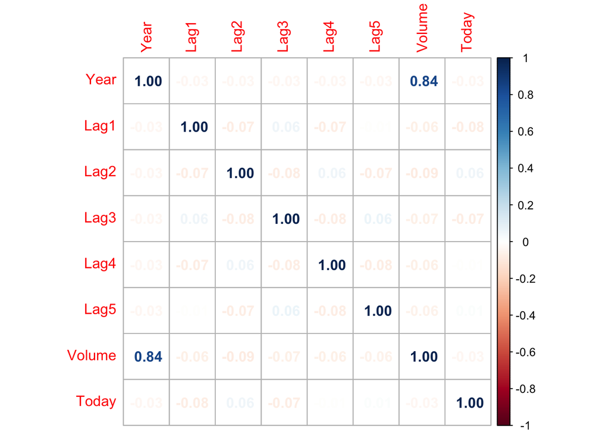

```r
# Looking at the relationships between the numeric variables
weekly_num <- dplyr::select_if(Weekly, is.numeric)
M = cor(weekly_num)
corrplot(M, method = c("number"))
```

Volume and Year appear to be correlated.

2. Use the full data set to perform a logistic regression with Direction as the response and the five lag variables plus Volume as predictors. Use the summary function to print the results. Do any of the predictors appear to be statistically significant? If so, which ones?

```r
m1 = glm(formula = Direction ~ Lag1 + Lag2 + Lag3 + Lag4 + Lag5 + Volume,data = Weekly, family = binomial)
summary(m1)
```

```
##
## Call:
## glm(formula = Direction ~ Lag1 + Lag2 + Lag3 + Lag4 + Lag5 +
##     Volume, family = binomial, data = Weekly)
##
## Coefficients:
##             Estimate Std. Error z value Pr(>|z|)
## (Intercept)  0.26686    0.08593   3.106   0.0019 **
## Lag1        -0.04127    0.02641  -1.563   0.1181
## Lag2         0.05844    0.02686   2.175   0.0296 *
## Lag3        -0.01606    0.02666  -0.602   0.5469
## Lag4        -0.02779    0.02646  -1.050   0.2937
## Lag5        -0.01447    0.02638  -0.549   0.5833
## Volume      -0.02274    0.03690  -0.616   0.5377
## ---
## Signif. codes:  0 '***' 0.001 '**' 0.01 '*' 0.05 '.' 0.1 ' ' 1
##
## (Dispersion parameter for binomial family taken to be 1)
##
##     Null deviance: 1496.2  on 1088  degrees of freedom
## Residual deviance: 1486.4  on 1082  degrees of freedom
## AIC: 1500.4
##
## Number of Fisher Scoring iterations: 4
```

```r
vif(m1)
```

```
##     Lag1     Lag2     Lag3     Lag4     Lag5   Volume
## 1.017298 1.023770 1.019378 1.027388 1.014676 1.024789
```

Lag2 appears to be statistically significant.

3. Compute the confusion matrix and overall fraction of correct predictions. Explain what the confusion matrix is telling you about the types of mistakes made by logistic regression.

```r
# Predicting the responses on m1
predprob_log <- predict.glm(m1, Weekly, type = "response")
predclass_log = ifelse(predprob_log >= 0.5, "Up", "Down")

# Confusion matrix
caret::confusionMatrix(as.factor(predclass_log), Weekly$Direction, positive = "Up")
```

```
## Confusion Matrix and Statistics
##
##           Reference
## Prediction Down  Up
##       Down   54  48
##       Up    430 557
##
##                Accuracy : 0.5611
##                  95% CI : (0.531, 0.5908)
##     No Information Rate : 0.5556
##     P-Value [Acc > NIR] : 0.369
##
##                   Kappa : 0.035
##
##  Mcnemar's Test P-Value : <2e-16
##
##             Sensitivity : 0.9207
##             Specificity : 0.1116
##          Pos Pred Value : 0.5643
##          Neg Pred Value : 0.5294
##              Prevalence : 0.5556
##          Detection Rate : 0.5115
##    Detection Prevalence : 0.9063
##       Balanced Accuracy : 0.5161
##
##        'Positive' Class : Up
##
```

```r
# Accuracy    : 0.5611
# Sensitivity : 0.9207
# Specificity : 0.1116
```

The model has high sensitivity and low specificity, meaning it correctly predicts up direction, but is quite bad at predicting the down direction. Overall, accuracy is 56%.

4. Now fit the logistic regression model using a training data period from 1990 to 2008, with Lag2 as the only predictor. Compute the confusion matrix and the overall fraction of correct predictions for the held out data (that is, the data from 2009 and 2010).

```r
#split into train and test
weekly_train = Weekly %>% filter(Weekly$Year < 2009)
weekly_test = Weekly %>% filter(Weekly$Year > 2008)
```

```r
m2 = glm(formula = Direction ~ Lag2,data = weekly_train, family = binomial)
summary(m2)
```

```
##
## Call:
## glm(formula = Direction ~ Lag2, family = binomial, data = weekly_train)
##
## Coefficients:
##             Estimate Std. Error z value Pr(>|z|)
## (Intercept)  0.20326    0.06428   3.162  0.00157 **
## Lag2         0.05810    0.02870   2.024  0.04298 *
## ---
## Signif. codes:  0 '***' 0.001 '**' 0.01 '*' 0.05 '.' 0.1 ' ' 1
##
## (Dispersion parameter for binomial family taken to be 1)
##
##     Null deviance: 1354.7  on 984  degrees of freedom
## Residual deviance: 1350.5  on 983  degrees of freedom
## AIC: 1354.5
##
## Number of Fisher Scoring iterations: 4
```

```r
# Predicting the responses on m2
predprob_log2 <- predict.glm(m2, weekly_test, type = "response")
predclass_log2 = ifelse(predprob_log2 >= 0.5, "Up", "Down")

# Confusion matrix
caret::confusionMatrix(as.factor(predclass_log2), weekly_test$Direction, positive = "Up")
```

```
## Confusion Matrix and Statistics
##
##           Reference
## Prediction Down Up
##       Down    9  5
##       Up     34 56
##
##                Accuracy : 0.625
##                  95% CI : (0.5247, 0.718)
##     No Information Rate : 0.5865
##     P-Value [Acc > NIR] : 0.2439
##
##                   Kappa : 0.1414
##
##  Mcnemar's Test P-Value : 7.34e-06
##
##             Sensitivity : 0.9180
##             Specificity : 0.2093
##          Pos Pred Value : 0.6222
##          Neg Pred Value : 0.6429
##              Prevalence : 0.5865
##          Detection Rate : 0.5385
##    Detection Prevalence : 0.8654
##       Balanced Accuracy : 0.5637
##
##        'Positive' Class : Up
##
```

5. Repeat (d) using LDA.

```r
lda.model = lda(Direction ~ Lag2, data = weekly_train)
lda.model
```

```
## Call:
## lda(Direction ~ Lag2, data = weekly_train)
##
## Prior probabilities of groups:
##      Down        Up
## 0.4477157 0.5522843
##
## Group means:
##             Lag2
## Down -0.03568254
## Up    0.26036581
##
## Coefficients of linear discriminants:
##            LD1
## Lag2 0.4414162
```

```r
predictions.lda = predict(lda.model, weekly_test)

caret::confusionMatrix(as.factor(predictions.lda$class), weekly_test$Direction)
```

```
## Confusion Matrix and Statistics
##
##           Reference
## Prediction Down Up
##       Down    9  5
##       Up     34 56
##
##                Accuracy : 0.625
##                  95% CI : (0.5247, 0.718)
##     No Information Rate : 0.5865
##     P-Value [Acc > NIR] : 0.2439
##
##                   Kappa : 0.1414
##
##  Mcnemar's Test P-Value : 7.34e-06
##
##             Sensitivity : 0.20930
##             Specificity : 0.91803
##          Pos Pred Value : 0.64286
##          Neg Pred Value : 0.62222
##              Prevalence : 0.41346
##          Detection Rate : 0.08654
##    Detection Prevalence : 0.13462
##       Balanced Accuracy : 0.56367
##
##        'Positive' Class : Down
##
```

6. Repeat (d) using QDA.

```r
qda.model = qda(Direction ~ Lag2, data = weekly_train)
qda.model
```

```
## Call:
## qda(Direction ~ Lag2, data = weekly_train)
##
## Prior probabilities of groups:
##      Down        Up
## 0.4477157 0.5522843
##
## Group means:
##             Lag2
## Down -0.03568254
## Up    0.26036581
```

```r
predictions.qda = predict(qda.model, weekly_test)

caret::confusionMatrix(as.factor(predictions.qda$class), weekly_test$Direction)
```

```
## Confusion Matrix and Statistics
##
##           Reference
## Prediction Down Up
##       Down    0  0
##       Up     43 61
##
##                Accuracy : 0.5865
##                  95% CI : (0.4858, 0.6823)
##     No Information Rate : 0.5865
##     P-Value [Acc > NIR] : 0.5419
##
##                   Kappa : 0
##
##  Mcnemar's Test P-Value : 1.504e-10
##
##             Sensitivity : 0.0000
##             Specificity : 1.0000
##          Pos Pred Value :    NaN
##          Neg Pred Value : 0.5865
##              Prevalence : 0.4135
##          Detection Rate : 0.0000
##    Detection Prevalence : 0.0000
##       Balanced Accuracy : 0.5000
##
##        'Positive' Class : Down
##
```

7. Repeat (d) using KNN with K = 1.

```r
#convert direction
weekly_train$Direction_dummy <- ifelse(weekly_train$Direction == "Up", 1, 0)
weekly_test$Direction_dummy <- ifelse(weekly_test$Direction == "Up", 1, 0)
```

```r
#KNN model
set.seed(1)
knn.model <- knn(train = as.matrix(weekly_train$Lag2), test = as.matrix(weekly_test$Lag2), cl = weekly_train$Direction_dummy, k = 1)
predclass_knn <- ifelse(knn.model == 1, "Up", "Down")
```

```r
confusionMatrix(as.factor(predclass_knn), weekly_test$Direction, positive = "Up")
```

```
## Confusion Matrix and Statistics
##
##           Reference
## Prediction Down Up
##       Down   21 30
##       Up     22 31
##
##                Accuracy : 0.5
##                  95% CI : (0.4003, 0.5997)
##     No Information Rate : 0.5865
##     P-Value [Acc > NIR] : 0.9700
##
##                   Kappa : -0.0033
##
##  Mcnemar's Test P-Value : 0.3317
##
##             Sensitivity : 0.5082
##             Specificity : 0.4884
##          Pos Pred Value : 0.5849
##          Neg Pred Value : 0.4118
##              Prevalence : 0.5865
##          Detection Rate : 0.2981
##    Detection Prevalence : 0.5096
##       Balanced Accuracy : 0.4983
##
##        'Positive' Class : Up
##
```

8. Repeat (d) using naive Bayes.

```r
nb.model = naiveBayes(Direction~Lag2 ,data=weekly_train)
predictions.nb = predict(nb.model, weekly_test)
caret::confusionMatrix(as.factor(predictions.nb), weekly_test$Direction)
```

```
## Confusion Matrix and Statistics
##
##           Reference
## Prediction Down Up
##       Down    0  0
##       Up     43 61
##
##                Accuracy : 0.5865
##                  95% CI : (0.4858, 0.6823)
##     No Information Rate : 0.5865
##     P-Value [Acc > NIR] : 0.5419
##
##                   Kappa : 0
##
##  Mcnemar's Test P-Value : 1.504e-10
##
##             Sensitivity : 0.0000
##             Specificity : 1.0000
##          Pos Pred Value :    NaN
##          Neg Pred Value : 0.5865
##              Prevalence : 0.4135
##          Detection Rate : 0.0000
##    Detection Prevalence : 0.0000
##       Balanced Accuracy : 0.5000
##
##        'Positive' Class : Down
##
```

1. Which of these methods appears to provide the best results on this data?

The logistic regression model appears to provide the best results with being able to correctly predict the outcome 62.5% of the time.

10. Experiment with different combinations of predictors, including possible transformations and interactions, for each of the methods. Report the variables, method, and associated confusion matrix that appears to provide the best results on the held out data. Note that you should also experiment with values for K in the KNN classifier.

```r
#KNN Model 2
set.seed(1)
knn.model2 <- knn(train = as.matrix(weekly_train$Lag2), test = as.matrix(weekly_test$Lag2), cl = weekly_train$Direction_dummy, k = 4)
predclass_knn2 <- ifelse(knn.model2 == 1, "Up", "Down")
confusionMatrix(as.factor(predclass_knn2), weekly_test$Direction, positive = "Up")
```

```
## Confusion Matrix and Statistics
##
##           Reference
## Prediction Down Up
##       Down   20 17
##       Up     23 44
##
##                Accuracy : 0.6154
##                  95% CI : (0.5149, 0.7091)
##     No Information Rate : 0.5865
##     P-Value [Acc > NIR] : 0.3110
##
##                   Kappa : 0.1903
##
##  Mcnemar's Test P-Value : 0.4292
##
##             Sensitivity : 0.7213
##             Specificity : 0.4651
##          Pos Pred Value : 0.6567
##          Neg Pred Value : 0.5405
##              Prevalence : 0.5865
##          Detection Rate : 0.4231
##    Detection Prevalence : 0.6442
##       Balanced Accuracy : 0.5932
##
##        'Positive' Class : Up
##
```

```r
#LDA Model 2
lda.model2 = lda(Direction ~ Lag2^2, data = weekly_train)
predictions.lda2 = predict(lda.model2, weekly_test)

caret::confusionMatrix(as.factor(predictions.lda2$class), weekly_test$Direction)
```

```
## Confusion Matrix and Statistics
##
##           Reference
## Prediction Down Up
##       Down    9  5
##       Up     34 56
##
##                Accuracy : 0.625
##                  95% CI : (0.5247, 0.718)
##     No Information Rate : 0.5865
##     P-Value [Acc > NIR] : 0.2439
##
##                   Kappa : 0.1414
##
##  Mcnemar's Test P-Value : 7.34e-06
##
##             Sensitivity : 0.20930
##             Specificity : 0.91803
##          Pos Pred Value : 0.64286
##          Neg Pred Value : 0.62222
##              Prevalence : 0.41346
##          Detection Rate : 0.08654
##    Detection Prevalence : 0.13462
##       Balanced Accuracy : 0.56367
##
##        'Positive' Class : Down
##
```

```r
qda.model2 = qda(Direction ~ Lag2^2, data = weekly_train)
predictions.qda2 = predict(qda.model2, weekly_test)
caret::confusionMatrix(as.factor(predictions.qda2$class), weekly_test$Direction)
```

```
## Confusion Matrix and Statistics
##
##           Reference
## Prediction Down Up
##       Down    0  0
##       Up     43 61
##
##                Accuracy : 0.5865
##                  95% CI : (0.4858, 0.6823)
##     No Information Rate : 0.5865
##     P-Value [Acc > NIR] : 0.5419
##
##                   Kappa : 0
##
##  Mcnemar's Test P-Value : 1.504e-10
##
##             Sensitivity : 0.0000
##             Specificity : 1.0000
##          Pos Pred Value :    NaN
##          Neg Pred Value : 0.5865
##              Prevalence : 0.4135
##          Detection Rate : 0.0000
##    Detection Prevalence : 0.0000
##       Balanced Accuracy : 0.5000
##
##        'Positive' Class : Down
##
```

Increasing K to 4 improved the accuracy from 50% to 61.5% for the KNN model. I tried squaring lag2 for QDA and LDA which didn’t change things.

### Question 14

In this problem, you will develop a model to predict whether a given car gets high or low gas mileage based on the Auto data set.

1. Create a binary variable, mpg01, that contains a 1 if mpg contains a value above its median, and a 0 if mpg contains a value below its median. You can compute the median using the median() function. Note you may find it helpful to use the data.frame() function to create a single data set containing both mpg01 and the other Auto variables.

```r
auto = data.frame(Auto)
auto$mpg01 = ifelse(auto$mpg > median(auto$mpg), 1, 0)
```

2. Explore the data graphically in order to investigate the association between mpg01 and the other features. Which of the other features seem most likely to be useful in predicting mpg01? Scatterplots and boxplots may be useful tools to answer this question. Describe your findings.

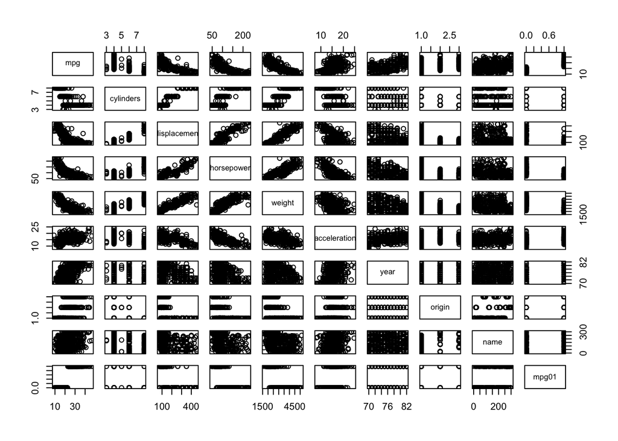

```r
pairs(auto)
```

```r
summary(auto)
```

```
##       mpg          cylinders      displacement     horsepower        weight
##  Min.   : 9.00   Min.   :3.000   Min.   : 68.0   Min.   : 46.0   Min.   :1613
##  1st Qu.:17.00   1st Qu.:4.000   1st Qu.:105.0   1st Qu.: 75.0   1st Qu.:2225
##  Median :22.75   Median :4.000   Median :151.0   Median : 93.5   Median :2804
##  Mean   :23.45   Mean   :5.472   Mean   :194.4   Mean   :104.5   Mean   :2978
##  3rd Qu.:29.00   3rd Qu.:8.000   3rd Qu.:275.8   3rd Qu.:126.0   3rd Qu.:3615
##  Max.   :46.60   Max.   :8.000   Max.   :455.0   Max.   :230.0   Max.   :5140
##
##   acceleration        year           origin                      name
##  Min.   : 8.00   Min.   :70.00   Min.   :1.000   amc matador       :  5
##  1st Qu.:13.78   1st Qu.:73.00   1st Qu.:1.000   ford pinto        :  5
##  Median :15.50   Median :76.00   Median :1.000   toyota corolla    :  5
##  Mean   :15.54   Mean   :75.98   Mean   :1.577   amc gremlin       :  4
##  3rd Qu.:17.02   3rd Qu.:79.00   3rd Qu.:2.000   amc hornet        :  4
##  Max.   :24.80   Max.   :82.00   Max.   :3.000   chevrolet chevette:  4
##                                                  (Other)           :365
##      mpg01
##  Min.   :0.0
##  1st Qu.:0.0
##  Median :0.5
##  Mean   :0.5
##  3rd Qu.:1.0
##  Max.   :1.0
##
```

```r
str(auto)
```

```
## 'data.frame':    392 obs. of  10 variables:
##  $ mpg         : num  18 15 18 16 17 15 14 14 14 15 ...
##  $ cylinders   : int  8 8 8 8 8 8 8 8 8 8 ...
##  $ displacement: num  307 350 318 304 302 429 454 440 455 390 ...
##  $ horsepower  : int  130 165 150 150 140 198 220 215 225 190 ...
##  $ weight      : int  3504 3693 3436 3433 3449 4341 4354 4312 4425 3850 ...
##  $ acceleration: num  12 11.5 11 12 10.5 10 9 8.5 10 8.5 ...
##  $ year        : int  70 70 70 70 70 70 70 70 70 70 ...
##  $ origin      : int  1 1 1 1 1 1 1 1 1 1 ...
##  $ name        : Factor w/ 304 levels "amc ambassador brougham",..: 49 36 231 14 161 141 54 223 241 2 ...
##  $ mpg01       : num  0 0 0 0 0 0 0 0 0 0 ...
```

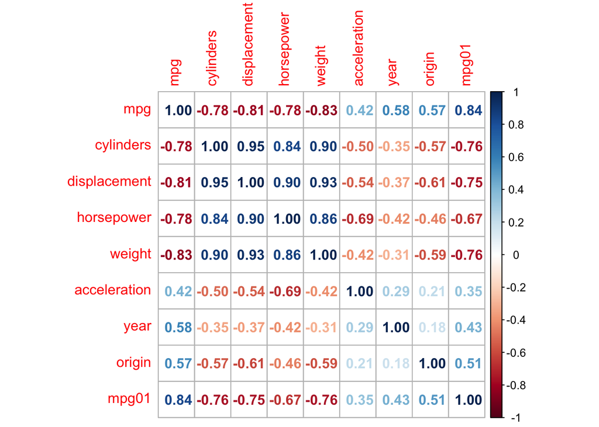

```r
# Correlation
auto_num <- dplyr::select_if(auto, is.numeric)
corrplot(cor(auto_num), method = c("number"))
```

It looks like cylinder, displacement, and weight are most correlated and horsepower and origin are also correlated (but a little less so).

3. Split the data into a training set and a test set.

```r
set.seed(1)
index = sample(nrow(auto), 0.8*nrow(auto), replace = F) # 80/20 split
auto_train = auto[index,]
auto_test = auto[-index,]
```

4. Perform LDA on the training data in order to predict mpg01 using the variables that seemed most associated with mpg01 in (b). What is the test error of the model obtained?

```r
auto.lda = lda(mpg01 ~ cylinders + displacement + weight + horsepower + origin, data= auto_train)
predictions.lda.auto = predict(auto.lda, auto_test)
caret::confusionMatrix(as.factor(predictions.lda.auto$class), as.factor(auto_test$mpg01))
```

```
## Confusion Matrix and Statistics
##
##           Reference
## Prediction  0  1
##          0 35  0
##          1  7 37
##
##                Accuracy : 0.9114
##                  95% CI : (0.8259, 0.9636)
##     No Information Rate : 0.5316
##     P-Value [Acc > NIR] : 2.819e-13
##
##                   Kappa : 0.8241
##
##  Mcnemar's Test P-Value : 0.02334
##
##             Sensitivity : 0.8333
##             Specificity : 1.0000
##          Pos Pred Value : 1.0000
##          Neg Pred Value : 0.8409
##              Prevalence : 0.5316
##          Detection Rate : 0.4430
##    Detection Prevalence : 0.4430
##       Balanced Accuracy : 0.9167
##
##        'Positive' Class : 0
##
```

The error for the LDA model is 8.86%.

5. Perform QDA on the training data in order to predict mpg01 using the variables that seemed most associated with mpg01 in (b). What is the test error of the model obtained?

```r
auto.qda = qda(mpg01 ~ cylinders + displacement + weight + horsepower + origin, data= auto_train)
predictions.qda.auto = predict(auto.qda, auto_test)
caret::confusionMatrix(as.factor(predictions.qda.auto$class), as.factor(auto_test$mpg01))
```

```
## Confusion Matrix and Statistics
##
##           Reference
## Prediction  0  1
##          0 36  2
##          1  6 35
##
##                Accuracy : 0.8987
##                  95% CI : (0.8102, 0.9553)
##     No Information Rate : 0.5316
##     P-Value [Acc > NIR] : 2.278e-12
##
##                   Kappa : 0.798
##
##  Mcnemar's Test P-Value : 0.2888
##
##             Sensitivity : 0.8571
##             Specificity : 0.9459
##          Pos Pred Value : 0.9474
##          Neg Pred Value : 0.8537
##              Prevalence : 0.5316
##          Detection Rate : 0.4557
##    Detection Prevalence : 0.4810
##       Balanced Accuracy : 0.9015
##
##        'Positive' Class : 0
##
```

The error for the QDA model is 10.13%.

6. Perform logistic regression on the training data in order to pre- dict mpg01 using the variables that seemed most associated with mpg01 in (b). What is the test error of the model obtained?

```r
auto.log = glm(formula = mpg01 ~ cylinders + displacement + weight + horsepower + origin,data = auto_train, family = binomial)
summary(auto.log)
```

```
##
## Call:
## glm(formula = mpg01 ~ cylinders + displacement + weight + horsepower +
##     origin, family = binomial, data = auto_train)
##
## Coefficients:
##                Estimate Std. Error z value Pr(>|z|)
## (Intercept)  11.4585601  1.9158183   5.981 2.22e-09 ***
## cylinders     0.0253531  0.3773978   0.067   0.9464
## displacement -0.0096120  0.0098606  -0.975   0.3297
## weight       -0.0022131  0.0007556  -2.929   0.0034 **
## horsepower   -0.0391871  0.0159680  -2.454   0.0141 *
## origin        0.0983464  0.3140504   0.313   0.7542
## ---
## Signif. codes:  0 '***' 0.001 '**' 0.01 '*' 0.05 '.' 0.1 ' ' 1
##
## (Dispersion parameter for binomial family taken to be 1)
##
##     Null deviance: 433.83  on 312  degrees of freedom
## Residual deviance: 175.03  on 307  degrees of freedom
## AIC: 187.03
##
## Number of Fisher Scoring iterations: 7
```

```r
auto.log2 = glm(formula = mpg01 ~ weight + horsepower,data = auto_train, family = binomial)
summary(auto.log2)
```

```
##
## Call:
## glm(formula = mpg01 ~ weight + horsepower, family = binomial,
##     data = auto_train)
##
## Coefficients:
##               Estimate Std. Error z value Pr(>|z|)
## (Intercept) 13.3163967  1.6294218   8.172 3.02e-16 ***
## weight      -0.0032154  0.0005163  -6.227 4.74e-10 ***
## horsepower  -0.0428774  0.0146233  -2.932  0.00337 **
## ---
## Signif. codes:  0 '***' 0.001 '**' 0.01 '*' 0.05 '.' 0.1 ' ' 1
##
## (Dispersion parameter for binomial family taken to be 1)
##
##     Null deviance: 433.83  on 312  degrees of freedom
## Residual deviance: 178.52  on 310  degrees of freedom
## AIC: 184.52
##
## Number of Fisher Scoring iterations: 7
```

```r
predprob_log_auto <- predict.glm(auto.log2, auto_test, type = "response")
predclass_log_auto = ifelse(predprob_log_auto >= 0.5, 1, 0)


caret::confusionMatrix(as.factor(predclass_log_auto), as.factor(auto_test$mpg01), positive = "1")
```

```
## Confusion Matrix and Statistics
##
##           Reference
## Prediction  0  1
##          0 36  4
##          1  6 33
##
##                Accuracy : 0.8734
##                  95% CI : (0.7795, 0.9376)
##     No Information Rate : 0.5316
##     P-Value [Acc > NIR] : 1.017e-10
##
##                   Kappa : 0.7466
##
##  Mcnemar's Test P-Value : 0.7518
##
##             Sensitivity : 0.8919
##             Specificity : 0.8571
##          Pos Pred Value : 0.8462
##          Neg Pred Value : 0.9000
##              Prevalence : 0.4684
##          Detection Rate : 0.4177
##    Detection Prevalence : 0.4937
##       Balanced Accuracy : 0.8745
##
##        'Positive' Class : 1
##
```

The error for the logistic model is 12.66%

7. Perform naive Bayes on the training data in order to predict mpg01 using the variables that seemed most associated with mpg01 in (b). What is the test error of the model obtained?

```r
auto.nb = naiveBayes(mpg01~ cylinders + displacement + weight + horsepower + origin,data=auto_train)
predictions.nb.auto = predict(auto.nb, auto_test)
caret::confusionMatrix(as.factor(predictions.nb.auto), as.factor(auto_test$mpg01))
```

```
## Confusion Matrix and Statistics
##
##           Reference
## Prediction  0  1
##          0 36  1
##          1  6 36
##
##                Accuracy : 0.9114
##                  95% CI : (0.8259, 0.9636)
##     No Information Rate : 0.5316
##     P-Value [Acc > NIR] : 2.819e-13
##
##                   Kappa : 0.8235
##
##  Mcnemar's Test P-Value : 0.1306
##
##             Sensitivity : 0.8571
##             Specificity : 0.9730
##          Pos Pred Value : 0.9730
##          Neg Pred Value : 0.8571
##              Prevalence : 0.5316
##          Detection Rate : 0.4557
##    Detection Prevalence : 0.4684
##       Balanced Accuracy : 0.9151
##
##        'Positive' Class : 0
##
```

8.86% error for the naive Bayes model.

8. Perform KNN on the training data, with several values of K, in order to predict mpg01. Use only the variables that seemed most associated with mpg01 in (b). What test errors do you obtain? Which value of K seems to perform the best on this data set?

```r
set.seed(1)
knn.model.auto <- knn(train = auto_train[, c("cylinders", "displacement", "weight", "horsepower", "origin")], test = auto_test[, c("cylinders", "displacement", "weight", "horsepower", "origin")], cl = auto_train$mpg01, k = 3)
predclass_knn_auto <- ifelse(knn.model.auto == 1, 1, 0)
confusionMatrix(as.factor(predclass_knn_auto), as.factor(auto_test$mpg01), positive = "1")
```

```
## Confusion Matrix and Statistics
##
##           Reference
## Prediction  0  1
##          0 38  4
##          1  4 33
##
##                Accuracy : 0.8987
##                  95% CI : (0.8102, 0.9553)
##     No Information Rate : 0.5316
##     P-Value [Acc > NIR] : 2.278e-12
##
##                   Kappa : 0.7967
##
##  Mcnemar's Test P-Value : 1
##
##             Sensitivity : 0.8919
##             Specificity : 0.9048
##          Pos Pred Value : 0.8919
##          Neg Pred Value : 0.9048
##              Prevalence : 0.4684
##          Detection Rate : 0.4177
##    Detection Prevalence : 0.4684
##       Balanced Accuracy : 0.8983
##
##        'Positive' Class : 1
##
```

```r
# KNN - Accuracy (sensitivity / specificity)
# 1 - 0.8734
# 2 - 0.8608
# 3 - 0.8987 (.8919 / .9048)
# 4 - 0.8987 (.8649 / .9286)
# 5 - 0.8987 (.8919 / .9048)
# 6 - 0.8987 (.9189 / .8810)
# 7 - 0.8987 (.9189 / .8810)
# 8 - 0.8861
```

Obtained 10.13% error for the KNN model. The K value of 3 seemed to perform the best.

### Question 16

Using the Boston data set, fit classification models in order to predict whether a given census tract has a crime rate above or below the median. Explore logistic regression, LDA, naive Bayes, and KNN models using various subsets of the predictors. Describe your findings. Hint: You will have to create the response variable yourself, using the variables that are contained in the Boston data set.

View(Boston)

```r
#create response variable
boston = data.frame(Boston)
boston$crime_rate = ifelse(boston$crim > median(boston$crim), 1, 0)
```

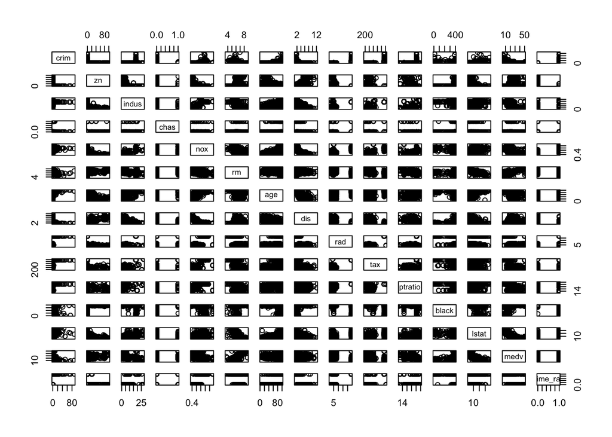

```r
pairs(boston)
```

```r
summary(boston)
```

```
##       crim                zn             indus            chas
##  Min.   : 0.00632   Min.   :  0.00   Min.   : 0.46   Min.   :0.00000
##  1st Qu.: 0.08205   1st Qu.:  0.00   1st Qu.: 5.19   1st Qu.:0.00000
##  Median : 0.25651   Median :  0.00   Median : 9.69   Median :0.00000
##  Mean   : 3.61352   Mean   : 11.36   Mean   :11.14   Mean   :0.06917
##  3rd Qu.: 3.67708   3rd Qu.: 12.50   3rd Qu.:18.10   3rd Qu.:0.00000
##  Max.   :88.97620   Max.   :100.00   Max.   :27.74   Max.   :1.00000
##       nox               rm             age              dis
##  Min.   :0.3850   Min.   :3.561   Min.   :  2.90   Min.   : 1.130
##  1st Qu.:0.4490   1st Qu.:5.886   1st Qu.: 45.02   1st Qu.: 2.100
##  Median :0.5380   Median :6.208   Median : 77.50   Median : 3.207
##  Mean   :0.5547   Mean   :6.285   Mean   : 68.57   Mean   : 3.795
##  3rd Qu.:0.6240   3rd Qu.:6.623   3rd Qu.: 94.08   3rd Qu.: 5.188
##  Max.   :0.8710   Max.   :8.780   Max.   :100.00   Max.   :12.127
##       rad              tax           ptratio          black
##  Min.   : 1.000   Min.   :187.0   Min.   :12.60   Min.   :  0.32
##  1st Qu.: 4.000   1st Qu.:279.0   1st Qu.:17.40   1st Qu.:375.38
##  Median : 5.000   Median :330.0   Median :19.05   Median :391.44
##  Mean   : 9.549   Mean   :408.2   Mean   :18.46   Mean   :356.67
##  3rd Qu.:24.000   3rd Qu.:666.0   3rd Qu.:20.20   3rd Qu.:396.23
##  Max.   :24.000   Max.   :711.0   Max.   :22.00   Max.   :396.90
##      lstat            medv         crime_rate
##  Min.   : 1.73   Min.   : 5.00   Min.   :0.0
##  1st Qu.: 6.95   1st Qu.:17.02   1st Qu.:0.0
##  Median :11.36   Median :21.20   Median :0.5
##  Mean   :12.65   Mean   :22.53   Mean   :0.5
##  3rd Qu.:16.95   3rd Qu.:25.00   3rd Qu.:1.0
##  Max.   :37.97   Max.   :50.00   Max.   :1.0
```

```r
str(boston)
```

```
## 'data.frame':    506 obs. of  15 variables:
##  $ crim      : num  0.00632 0.02731 0.02729 0.03237 0.06905 ...
##  $ zn        : num  18 0 0 0 0 0 12.5 12.5 12.5 12.5 ...
##  $ indus     : num  2.31 7.07 7.07 2.18 2.18 2.18 7.87 7.87 7.87 7.87 ...
##  $ chas      : int  0 0 0 0 0 0 0 0 0 0 ...
##  $ nox       : num  0.538 0.469 0.469 0.458 0.458 0.458 0.524 0.524 0.524 0.524 ...
##  $ rm        : num  6.58 6.42 7.18 7 7.15 ...
##  $ age       : num  65.2 78.9 61.1 45.8 54.2 58.7 66.6 96.1 100 85.9 ...
##  $ dis       : num  4.09 4.97 4.97 6.06 6.06 ...
##  $ rad       : int  1 2 2 3 3 3 5 5 5 5 ...
##  $ tax       : num  296 242 242 222 222 222 311 311 311 311 ...
##  $ ptratio   : num  15.3 17.8 17.8 18.7 18.7 18.7 15.2 15.2 15.2 15.2 ...
##  $ black     : num  397 397 393 395 397 ...
##  $ lstat     : num  4.98 9.14 4.03 2.94 5.33 ...
##  $ medv      : num  24 21.6 34.7 33.4 36.2 28.7 22.9 27.1 16.5 18.9 ...
##  $ crime_rate: num  0 0 0 0 0 0 0 0 0 0 ...
```

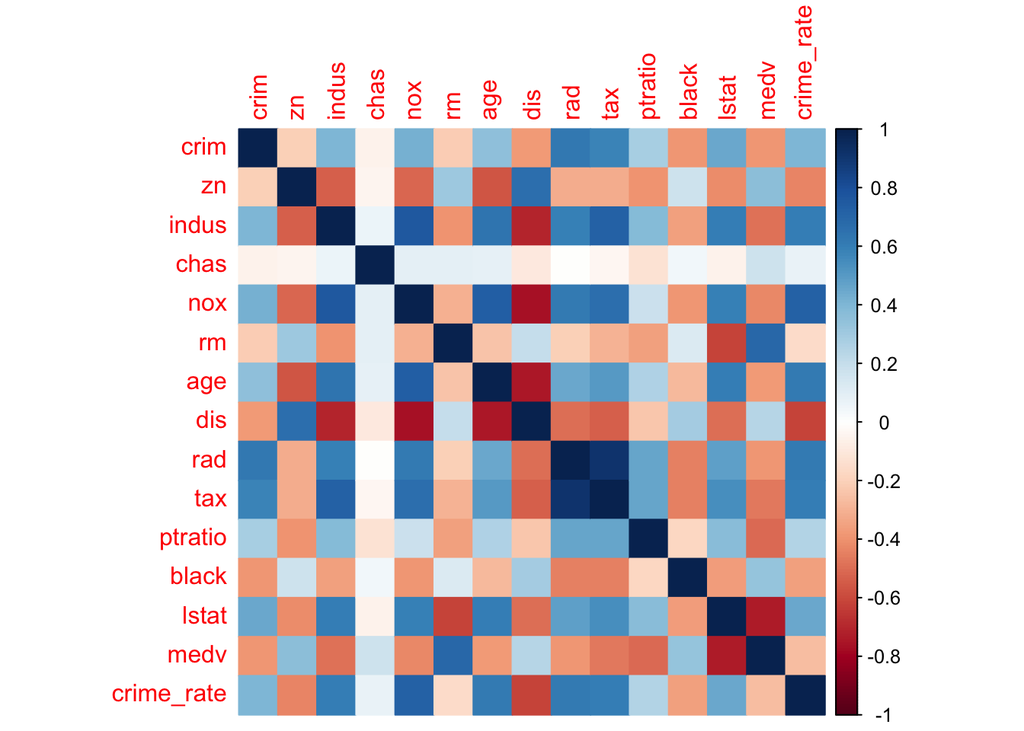

```r
# Correlation
corrplot(cor(boston), method = c("color"))
```

```r
#boston$chas = as.factor(boston$chas)
#boston$crime_rate = as.factor(boston$crime_rate)

### Splitting into test and train
set.seed(1)
ind = sample(nrow(boston), 0.8*nrow(boston), replace = F)
boston_train = boston[ind,]
boston_test = boston[-ind,]
```

```r
# Logistic Regression
b1 = glm(formula = crime_rate ~ . -crim, data = boston_train, family = binomial)
summary(b1)
```

```
##
## Call:
## glm(formula = crime_rate ~ . - crim, family = binomial, data = boston_train)
##
## Coefficients:
##               Estimate Std. Error z value Pr(>|z|)
## (Intercept) -42.886750   7.627711  -5.622 1.88e-08 ***
## zn           -0.106512   0.042954  -2.480 0.013149 *
## indus        -0.064955   0.051562  -1.260 0.207759
## chas          0.473349   0.786069   0.602 0.547059
## nox          56.659757   9.246096   6.128 8.90e-10 ***
## rm           -0.116177   0.846737  -0.137 0.890868
## age           0.021587   0.013568   1.591 0.111610
## dis           1.068641   0.278562   3.836 0.000125 ***
## rad           0.696528   0.175753   3.963 7.40e-05 ***
## tax          -0.007585   0.003075  -2.466 0.013646 *
## ptratio       0.362327   0.148310   2.443 0.014564 *
## black        -0.010208   0.005643  -1.809 0.070462 .
## lstat         0.078033   0.055794   1.399 0.161939
## medv          0.165209   0.080364   2.056 0.039806 *
## ---
## Signif. codes:  0 '***' 0.001 '**' 0.01 '*' 0.05 '.' 0.1 ' ' 1
##
## (Dispersion parameter for binomial family taken to be 1)
##
##     Null deviance: 560.06  on 403  degrees of freedom
## Residual deviance: 159.83  on 390  degrees of freedom
## AIC: 187.83
##
## Number of Fisher Scoring iterations: 9
```

```r
vif(b1)
```

```
##       zn    indus     chas      nox       rm      age      dis      rad
## 2.361049 2.895022 1.300142 5.296846 6.570467 2.594352 5.457461 2.128960
##      tax  ptratio    black    lstat     medv
## 1.863511 2.288799 1.063539 2.594020 9.685458
```

```r
# log model #1
predprob_log_boston <- predict.glm(b1, boston_test, type = "response")
predclass_log_boston = ifelse(predprob_log_boston >= 0.5,yes = 1,0)
caret::confusionMatrix(as.factor(predclass_log_boston), as.factor(boston_test$crime_rate), positive = "1")
```

```
## Confusion Matrix and Statistics
##
##           Reference
## Prediction  0  1
##          0 43  5
##          1  8 46
##
##                Accuracy : 0.8725
##                  95% CI : (0.7919, 0.9304)
##     No Information Rate : 0.5
##     P-Value [Acc > NIR] : 2.151e-15
##
##                   Kappa : 0.7451
##
##  Mcnemar's Test P-Value : 0.5791
##
##             Sensitivity : 0.9020
##             Specificity : 0.8431
##          Pos Pred Value : 0.8519
##          Neg Pred Value : 0.8958
##              Prevalence : 0.5000
##          Detection Rate : 0.4510
##    Detection Prevalence : 0.5294
##       Balanced Accuracy : 0.8725
##
##        'Positive' Class : 1
##
```

```r
# Stepwise Selection with AIC
null_model = glm(crime_rate ~ 1, data = boston_train, family = binomial)
full_model = b1
step.model.AIC = step(null_model, scope = list(upper = full_model),
                      direction = "both", test = "Chisq", trace = F)
summary(step.model.AIC)
```

```
##
## Call:
## glm(formula = crime_rate ~ nox + rad + tax + ptratio + dis +
##     zn + medv + age + black, family = binomial, data = boston_train)
##
## Coefficients:
##               Estimate Std. Error z value Pr(>|z|)
## (Intercept) -39.519412   7.216180  -5.477 4.34e-08 ***
## nox          51.313423   8.113413   6.325 2.54e-10 ***
## rad           0.771994   0.163016   4.736 2.18e-06 ***
## tax          -0.008798   0.002901  -3.033 0.002422 **
## ptratio       0.353281   0.135071   2.616 0.008909 **
## dis           1.009916   0.270475   3.734 0.000189 ***
## zn           -0.105917   0.039137  -2.706 0.006803 **
## medv          0.128740   0.040097   3.211 0.001324 **
## age           0.026176   0.011561   2.264 0.023557 *
## black        -0.010232   0.005731  -1.786 0.074176 .
## ---
## Signif. codes:  0 '***' 0.001 '**' 0.01 '*' 0.05 '.' 0.1 ' ' 1
##
## (Dispersion parameter for binomial family taken to be 1)
##
##     Null deviance: 560.06  on 403  degrees of freedom
## Residual deviance: 163.54  on 394  degrees of freedom
## AIC: 183.54
##
## Number of Fisher Scoring iterations: 9
```

```r
# Best model based on stepwise
b2 <- glm(crime_rate ~ nox + rad + tax + ptratio + dis + zn + medv + age + black, boston_train, family = binomial)

# log model #2

predprob_log_boston2 <- predict.glm(b2, boston_test, type = "response")
predclass_log_boston2 = ifelse(predprob_log_boston2 >= 0.5,yes = 1,0)
caret::confusionMatrix(as.factor(predclass_log_boston2), as.factor(boston_test$crime_rate), positive = "1")
```

```
## Confusion Matrix and Statistics
##
##           Reference
## Prediction  0  1
##          0 45  6
##          1  6 45
##
##                Accuracy : 0.8824
##                  95% CI : (0.8035, 0.9377)
##     No Information Rate : 0.5
##     P-Value [Acc > NIR] : 3.063e-16
##
##                   Kappa : 0.7647
##
##  Mcnemar's Test P-Value : 1
##
##             Sensitivity : 0.8824
##             Specificity : 0.8824
##          Pos Pred Value : 0.8824
##          Neg Pred Value : 0.8824
##              Prevalence : 0.5000
##          Detection Rate : 0.4412
##    Detection Prevalence : 0.5000
##       Balanced Accuracy : 0.8824
##
##        'Positive' Class : 1
##
```

```r
# LDA
boston.lda = lda(crime_rate ~ nox + rad + tax + ptratio + dis + zn + medv + age + black, data= boston_train)
predictions.lda.boston = predict(boston.lda, boston_test)
caret::confusionMatrix(as.factor(predictions.lda.boston$class), as.factor(boston_test$crime_rate))
```

```
## Confusion Matrix and Statistics
##
##           Reference
## Prediction  0  1
##          0 50 13
##          1  1 38
##
##                Accuracy : 0.8627
##                  95% CI : (0.7804, 0.9229)
##     No Information Rate : 0.5
##     P-Value [Acc > NIR] : 1.388e-14
##
##                   Kappa : 0.7255
##
##  Mcnemar's Test P-Value : 0.003283
##
##             Sensitivity : 0.9804
##             Specificity : 0.7451
##          Pos Pred Value : 0.7937
##          Neg Pred Value : 0.9744
##              Prevalence : 0.5000
##          Detection Rate : 0.4902
##    Detection Prevalence : 0.6176
##       Balanced Accuracy : 0.8627
##
##        'Positive' Class : 0
##
```

```r
# Naive Bayes

boston.nb = naiveBayes(crime_rate ~ nox + rad + tax + ptratio + dis + zn + medv + age + black,data=boston_train)
predictions.nb.boston = predict(boston.nb, boston_test)
caret::confusionMatrix(as.factor(predictions.nb.boston), as.factor(boston_test$crime_rate))
```

```
## Confusion Matrix and Statistics
##
##           Reference
## Prediction  0  1
##          0 47 15
##          1  4 36
##
##                Accuracy : 0.8137
##                  95% CI : (0.7245, 0.884)
##     No Information Rate : 0.5
##     P-Value [Acc > NIR] : 5.079e-11
##
##                   Kappa : 0.6275
##
##  Mcnemar's Test P-Value : 0.02178
##
##             Sensitivity : 0.9216
##             Specificity : 0.7059
##          Pos Pred Value : 0.7581
##          Neg Pred Value : 0.9000
##              Prevalence : 0.5000
##          Detection Rate : 0.4608
##    Detection Prevalence : 0.6078
##       Balanced Accuracy : 0.8137
##
##        'Positive' Class : 0
##
```

```r
# KNN
set.seed(1)
knn.model.boston <- knn(train = boston_train[, c("nox", "rad", "tax", "ptratio", "dis", "zn","medv","age","black")], test = boston_test[, c("nox", "rad", "tax", "ptratio", "dis", "zn","medv","age","black")], cl = boston_train$crime_rate, k = 2)
predclass_knn_boston <- ifelse(knn.model.boston == 1, 1, 0)
confusionMatrix(as.factor(predclass_knn_boston), as.factor(boston_test$crime_rate), positive = "1")
```

```
## Confusion Matrix and Statistics
##
##           Reference
## Prediction  0  1
##          0 45  3
##          1  6 48
##
##                Accuracy : 0.9118
##                  95% CI : (0.8391, 0.9589)
##     No Information Rate : 0.5
##     P-Value [Acc > NIR] : <2e-16
##
##                   Kappa : 0.8235
##
##  Mcnemar's Test P-Value : 0.505
##
##             Sensitivity : 0.9412
##             Specificity : 0.8824
##          Pos Pred Value : 0.8889
##          Neg Pred Value : 0.9375
##              Prevalence : 0.5000
##          Detection Rate : 0.4706
##    Detection Prevalence : 0.5294
##       Balanced Accuracy : 0.9118
##
##        'Positive' Class : 1
##
```

```r
# KNN - Accuracy
# 1 - 0.902
# 2 - 0.9118
# 3 - 0.902
# 4 - 0.902
# 5 - 0.8922
# 6 - 0.8824
# 8 - 0.8725
```

The model with the highest accuracy was the KNN model when K=2. This model has an accuracy of 91.18%. According to stepwise selection, the best model includes nox, rad, tax, ptratio, dis, zn, medv, age, and black.